# Headspace sample processing Part 2

# Description

Calculate dissolved gas concentrations for headspace samples from PPM data. Then insert dissolved gas concentration data into database.

# Data

- Get PPM data from database for source air and samples
- ppmv data for source gas - determined from GC workflow
- ppmv data for sample gas - determined from GC workflow
- water temperature - measured in the field or offset from GSODR
- barometric pressure - measured in the field or from GSODR data
- source gas sample volume - default 20 mL
- sample gas sample volume - default 40 mL

**PPM data**

Reshape the data so there is one row for each headspace sample with the required inputs for the `def.calc.sdg()` function.

```r
hs_sources <- db_get_hs_sources()
hs_sources %>% kable()
```

| source | hs |
| --- | --- |
| KLH Feb18 QBair | KLH 576 |
| KLH Feb18 QBair | KLH 596 |
| KLH Feb18 QBair | KLH 584 |
| KLH 519 | KLH 542 |
| KLH 519 | KLH 527 |
| KLH 519 | KLH 516 |
| KLH 506 | KLH 504 |
| KLH 506 | KLH 548 |
| KLH 506 | KLH 595 |
| KLH 501 | KLH 509 |
| KLH 501 | KLH 510 |
| KLH 501 | KLH 512 |
| KLH 501 | KLH 528 |
| KLH 501 | KLH 524 |
| KLH 501 | KLH 502 |
| KLH 620 | KLH 685 |
| KLH 620 | KLH 653 |
| KLH 620 | KLH 695 |
| KLH 521 | KLH Feb18xx105 |
| KLH 521 | KLH Feb18xx106 |
| KLH 521 | KLH Feb18xx107 |
| KLH 521 | KLH 594 |
| KLH 521 | KLH Feb18xx108 |
| KLH 521 | KLH Feb18xx101 |
| KLH 521 | KLH Feb18xx102 |
| KLH 521 | KLH Feb18xx103 |

Get the methane and co2 ppm data for each sample

```r
db_get_gc_data <- function(){
sql <- "SELECT sf.samplingfeaturecode, v.variablecode, u.unitsname, mrv.datavalue, mrv.valuedatetime
  FROM odm2.measurementresultvalues mrv, odm2.results r, odm2.variables v, odm2.units u, odm2.samplingfeatures sf, odm2.featureactions fa, odm2.methods m, odm2.actions act
 WHERE r.variableid = v.variableid
 AND fa.actionid = act.actionid
 AND act.methodid = m.methodid
 AND r.featureactionid = fa.featureactionid
 AND fa.samplingfeatureid = sf.samplingfeatureid
 AND r.unitsid = u.unitsid
 AND mrv.resultid = r.resultid
 AND r.sampledmediumcv = 'gas'
 AND m.methodcode = 'GC'"

sql <- gsub("\n", "", sql)
dbGetQuery(db, sql)
}
```

```r
ppms <- db_get_gc_data()
ppms %>% kable()
```

| samplingfeaturecode | variablecode | unitsname | datavalue | valuedatetime |
| --- | --- | --- | --- | --- |
| KLH Feb18 QBair | methane | Part per Million | 2.029568 | 2018-02-09 11:23:00 |
| KLH Feb18 QBair | carbonDioxide | Part per Million | 496.382712 | 2018-02-09 11:23:00 |
| KLH 576 | methane | Part per Million | 730.323375 | 2018-02-09 11:17:00 |
| KLH 576 | carbonDioxide | Part per Million | 5820.068979 | 2018-02-09 11:17:00 |
| KLH 596 | methane | Part per Million | 2.148277 | 2018-02-09 11:17:00 |
| KLH 596 | carbonDioxide | Part per Million | 451.469448 | 2018-02-09 11:17:00 |
| KLH 584 | methane | Part per Million | 2.032214 | 2018-02-09 11:17:00 |
| KLH 584 | carbonDioxide | Part per Million | 445.360793 | 2018-02-09 11:17:00 |
| KLH 542 | methane | Part per Million | 99.374436 | 2018-02-09 12:35:00 |
| KLH 542 | carbonDioxide | Part per Million | 6174.868464 | 2018-02-09 12:35:00 |
| KLH 527 | methane | Part per Million | 106.165253 | 2018-02-09 12:35:00 |
| KLH 527 | carbonDioxide | Part per Million | 6689.316202 | 2018-02-09 12:35:00 |
| KLH 516 | methane | Part per Million | 97.674687 | 2018-02-09 12:35:00 |
| KLH 516 | carbonDioxide | Part per Million | 5797.360243 | 2018-02-09 12:35:00 |
| KLH 519 | methane | Part per Million | 2.171462 | 2018-02-09 12:38:00 |
| KLH 519 | carbonDioxide | Part per Million | 502.297759 | 2018-02-09 12:38:00 |
| KLH 506 | methane | Part per Million | 2.407470 | 2018-02-09 13:25:00 |
| KLH 506 | carbonDioxide | Part per Million | 469.225677 | 2018-02-09 13:25:00 |
| KLH 504 | methane | Part per Million | 14.565674 | 2018-02-09 13:15:00 |
| KLH 504 | carbonDioxide | Part per Million | 1443.929847 | 2018-02-09 13:15:00 |
| KLH 548 | methane | Part per Million | 1527.396660 | 2018-02-09 13:15:00 |
| KLH 548 | carbonDioxide | Part per Million | 9153.492199 | 2018-02-09 13:15:00 |
| KLH 595 | methane | Part per Million | 59.744374 | 2018-02-09 13:15:00 |
| KLH 595 | carbonDioxide | Part per Million | 5056.584236 | 2018-02-09 13:15:00 |
| KLH 509 | methane | Part per Million | 801.205242 | 2018-02-09 14:05:00 |
| KLH 509 | carbonDioxide | Part per Million | 4809.874312 | 2018-02-09 14:05:00 |
| KLH 510 | methane | Part per Million | 805.791755 | 2018-02-09 14:05:00 |
| KLH 510 | carbonDioxide | Part per Million | 5203.087401 | 2018-02-09 14:05:00 |
| KLH 512 | methane | Part per Million | 791.406166 | 2018-02-09 14:05:00 |
| KLH 512 | carbonDioxide | Part per Million | 4213.996814 | 2018-02-09 14:05:00 |
| KLH 697 | methane | Part per Million | 2.242410 | 2018-02-09 15:15:00 |
| KLH 697 | carbonDioxide | Part per Million | 431.403871 | 2018-02-09 15:15:00 |
| KLH 528 | methane | Part per Million | 4295.927098 | 2018-02-09 14:40:00 |
| KLH 528 | carbonDioxide | Part per Million | 4231.476493 | 2018-02-09 14:40:00 |
| KLH 524 | methane | Part per Million | 3408.893158 | 2018-02-09 14:40:00 |
| KLH 524 | carbonDioxide | Part per Million | 4926.905070 | 2018-02-09 14:40:00 |
| KLH 502 | methane | Part per Million | 3431.364490 | 2018-02-09 14:40:00 |
| KLH 502 | carbonDioxide | Part per Million | 4693.552419 | 2018-02-09 14:40:00 |
| KLH 620 | methane | Part per Million | 2.129146 | 2018-02-09 15:40:00 |
| KLH 620 | carbonDioxide | Part per Million | 418.922845 | 2018-02-09 15:40:00 |
| KLH 685 | methane | Part per Million | 904.730628 | 2018-02-09 15:35:00 |
| KLH 685 | carbonDioxide | Part per Million | 7087.132907 | 2018-02-09 15:35:00 |
| KLH 653 | methane | Part per Million | 674.477007 | 2018-02-09 15:35:00 |
| KLH 653 | carbonDioxide | Part per Million | 5211.870791 | 2018-02-09 15:35:00 |
| KLH 695 | methane | Part per Million | 918.258276 | 2018-02-09 15:35:00 |
| KLH 695 | carbonDioxide | Part per Million | 7126.903287 | 2018-02-09 15:35:00 |
| KLH Feb18xx105 | methane | Part per Million | 823.579684 | 2018-02-09 16:20:00 |
| KLH Feb18xx105 | carbonDioxide | Part per Million | 5640.572258 | 2018-02-09 16:20:00 |
| KLH Feb18xx106 | methane | Part per Million | 635.973665 | 2018-02-09 16:20:00 |
| KLH Feb18xx106 | carbonDioxide | Part per Million | 8247.290162 | 2018-02-09 16:20:00 |
| KLH Feb18xx107 | methane | Part per Million | 2.246911 | 2018-02-09 16:20:00 |
| KLH Feb18xx107 | carbonDioxide | Part per Million | 404.137951 | 2018-02-09 16:20:00 |
| KLH Feb18xx108 | methane | Part per Million | 185.454589 | 2018-02-09 16:25:00 |
| KLH Feb18xx108 | carbonDioxide | Part per Million | 9183.415343 | 2018-02-09 16:25:00 |
| KLH Feb18xx101 | methane | Part per Million | 713.500501 | 2018-02-09 16:10:00 |
| KLH Feb18xx101 | carbonDioxide | Part per Million | 5426.914742 | 2018-02-09 16:10:00 |
| KLH Feb18xx102 | methane | Part per Million | 2.285994 | 2018-02-09 16:10:00 |
| KLH Feb18xx102 | carbonDioxide | Part per Million | 421.261672 | 2018-02-09 16:10:00 |
| KLH Feb18xx103 | methane | Part per Million | 358.888264 | 2018-02-09 16:10:00 |
| KLH Feb18xx103 | carbonDioxide | Part per Million | 5110.820030 | 2018-02-09 16:10:00 |
| KLH 521 | methane | Part per Million | 2.067191 | 2018-02-09 16:40:00 |
| KLH 521 | carbonDioxide | Part per Million | 479.914791 | 2018-02-09 16:40:00 |

Now we have hs sources and the ppm data. Join in wide format for the sdg function

```r
sdg_data <- hs_sources %>%
  left_join(ppms, by = c("source" = "samplingfeaturecode")) %>%
  dplyr::select(-unitsname, -valuedatetime) %>%
  filter(variablecode %in% c("carbonDioxide", "methane")) %>%
  spread(key = variablecode, value = datavalue) %>%
  rename(concentrationCO2Air = carbonDioxide, concentrationCH4Air = methane) %>%
  left_join(ppms, by = c("hs" = "samplingfeaturecode")) %>%
  dplyr::select(-unitsname) %>%
  filter(variablecode %in% c("carbonDioxide", "methane")) %>%
  spread(key = variablecode, value = datavalue) %>%
  rename(concentrationCO2Gas = carbonDioxide, concentrationCH4Gas = methane)
```

get table of where each sample was collected

```r
sql <- "SELECT * FROM odm2.relatedfeatures WHERE relationshiptypecv = 'wasCollectedAt'"
sql <- gsub("\n", "", sql)
rf <- dbGetQuery(db, sql)
sampfeatures <- dbReadTable(db, c("odm2", "samplingfeatures"))
samps_join_sites <- rf %>%
  left_join(sampfeatures, by = c("samplingfeatureid" = "samplingfeatureid")) %>%
  dplyr::select(relationid, samplingfeaturecode, relationshiptypecv, relatedfeatureid) %>%
  rename(specimencode = samplingfeaturecode) %>%
  left_join(sampfeatures, by = c("relatedfeatureid" = "samplingfeatureid")) %>%
  dplyr::select(specimencode, relationshiptypecv, samplingfeaturecode)
kable(samps_join_sites)
```

| specimencode | relationshiptypecv | samplingfeaturecode |
| --- | --- | --- |
| KLH Feb18 QBair | wasCollectedAt | QB |
| KLH 576 | wasCollectedAt | QB |
| KLH 596 | wasCollectedAt | QB |
| KLH 584 | wasCollectedAt | QB |
| KLH 542 | wasCollectedAt | ND |
| KLH 527 | wasCollectedAt | ND |
| KLH 516 | wasCollectedAt | ND |
| KLH 519 | wasCollectedAt | ND |
| KLH 506 | wasCollectedAt | DK |
| KLH 504 | wasCollectedAt | DK |
| KLH 548 | wasCollectedAt | DK |
| KLH 595 | wasCollectedAt | DK |
| KLH 501 | wasCollectedAt | BBout |
| KLH 509 | wasCollectedAt | BBout |
| KLH 510 | wasCollectedAt | BBout |
| KLH 512 | wasCollectedAt | BBout |
| KLH 697 | wasCollectedAt | BB |
| KLH 528 | wasCollectedAt | BB |
| KLH 524 | wasCollectedAt | BB |
| KLH 502 | wasCollectedAt | BB |
| KLH 620 | wasCollectedAt | DB |
| KLH 685 | wasCollectedAt | DB |
| KLH 653 | wasCollectedAt | DB |
| KLH 695 | wasCollectedAt | DB |
| KLH Feb18xx105 | wasCollectedAt | TBwell |
| KLH Feb18xx106 | wasCollectedAt | TBwell |
| KLH Feb18xx107 | wasCollectedAt | TBwell |
| KLH 594 | wasCollectedAt | TBin |
| KLH Feb18xx108 | wasCollectedAt | TBin |
| KLH Feb18xx101 | wasCollectedAt | TBout |
| KLH Feb18xx102 | wasCollectedAt | TBout |
| KLH Feb18xx103 | wasCollectedAt | TBout |
| KLH 521 | wasCollectedAt | TB |

add sites to sdg data

```r
sdg_data %<>% left_join(samps_join_sites, by = c("hs" = "specimencode")) %>%
  dplyr::select(- relationshiptypecv) %>% rename(site = samplingfeaturecode)
```

**Water Temp**

add in water temp data from field data collection.

**Barometric pressure**

Add column for barometric pressure and temp on day of sampling from Dover AFB GSOD data.

```r
gsod <- read_csv("data/gsod_data.csv")
```

convert gsod data from mb to kPa

```r
gsod$STP_kPa <- gsod$STP*0.1
gsod$TEMP_C <- gsod$TEMP
```

relevant columns in gsod data are YEARMODA, STP_kPa, TEMP. TEMP is mean daily temperature in Celcius (GSOD package does conversion to SI units).

```r
sdg_data$date <- date(sdg_data$valuedatetime)
gsod %<>% dplyr::select(YEARMODA, STP_kPa, TEMP_C)
sdg_data %<>% left_join(gsod, by = c("date" = "YEARMODA"))
```

```r
sdg_data$concentrationN2OAir = NA
sdg_data$concentrationN2OGas = NA
sdg_data %<>% mutate(headspaceTemp = TEMP_C) %>%
  rename(barometricPressure = STP_kPa, waterTemp = TEMP_C) %>%
  mutate(gasVolume = 20, waterVolume = 40)
```

# Calculations

Calculations are based on the NEON dissolved gas function. Add proper citation to [here](https://github.com/NEONScience/NEON-dissolved-gas).

```r
source('def.calc.sdg.R')
```

Use function by supplying column names and defaults. Output is concentrations and 100% saturation concentrations as additional columns on the data frame.

```r
sdg_out <- def.calc.sdg(inputFile = sdg_data)
```

output is in [M]

```r
sdg_results <- sdg_out %>%
  mutate(dissolvedCH4_umol = dissolvedCH4 * 1e6,
         dissolvedCO2_umol = dissolvedCO2 * 1e6,
         satCH4_umol = satCH4 * 1e6) %>%
  dplyr::select(hs, site, date, valuedatetime, dissolvedCH4_umol, dissolvedCO2_umol, satCH4_umol)
```

# Plots

woo data!

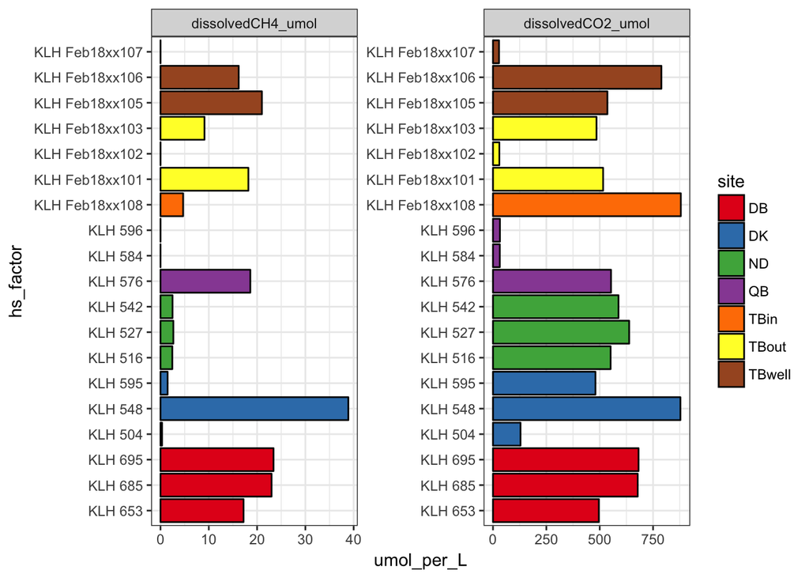

```r
# make the hs id a factor with the order corresponding to what site the samples are from
sdg_results$hs_factor <- factor(sdg_results$hs, ordered = TRUE, levels = sdg_results[order(sdg_results$site),"hs"])

sdg_results %>%
  gather(key = gas, value = umol_per_L, dissolvedCH4_umol:satCH4_umol) %>%
  filter(gas %in% c("dissolvedCH4_umol", "dissolvedCO2_umol")) %>%
  ggplot(aes(x = hs_factor, y = umol_per_L, fill = site)) +
  geom_bar(stat = "identity", col = "black", position = position_dodge()) +
  facet_wrap(~gas, scales = "free") +
  coord_flip() +
  theme_bw() +
  scale_fill_brewer(palette = "Set1")
```

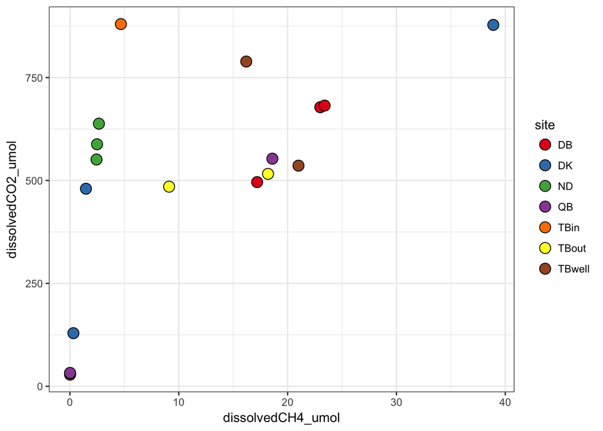

```r
sdg_results %>%
  ggplot(aes(x = dissolvedCH4_umol, y = dissolvedCO2_umol, fill = site)) +
  geom_point(pch = 21, col = "black", size = 4) +
  theme_bw() +
  scale_fill_brewer(palette = "Set1")
```

```r
  # scale_y_log10() + scale_x_log10()
```

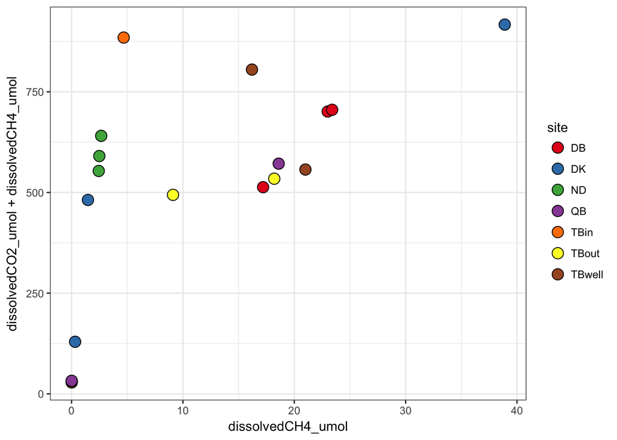

```r
sdg_results %>%
  ggplot(aes(x = dissolvedCH4_umol, y = dissolvedCO2_umol + dissolvedCH4_umol, fill = site)) +
  geom_point(pch = 21, col = "black", size = 4) +
  theme_bw() +
  scale_fill_brewer(palette = "Set1")
```

Reshape concentration data to put values in database for each sample

# Insert concentration results

Look at the data and assess for quality - add marginal quality code to samples that seem to not be right.

```r
sdg_results$qualitycode <- "unknown"
flag_marginal <- c("KLH Feb18xx107", "KLH Feb18xx102", "KLH 596", "KLH 584", "KLH 595", "KLH 504")
sdg_results[sdg_results$hs %in% flag_marginal, "qualitycode"] <- "marginal"
```

check for variables and units

```r
db_add_new_variable(variabletypecv = "WaterQuality", variablecode = "carbonDioxideDissolved",
                    variablenamecv = "Carbon Dioxide, dissolved", variabledefinition = "Dissolved Carbon dioxide (CO2)")
```

```r
dbGetQuery(db, "SELECT * FROM odm2.units WHERE unitsname = 'Micromole per Liter'")
```

```
##   unitsid                    unitstypecv unitsabbreviation
## 1     263 Concentration count per volume  \xb5mol/L; \xb5M
##             unitsname unitslink
## 1 Micromole per Liter      <NA>
```

```r
source('R/db_add_method.R')
db_add_method(methodtypecv = "derivation",
              methodcode = "calc_sdg",
              methodname = "Calculate dissolved gas concentration",
              methoddescription = "Calculate dissolved gas concentration in surface water based on headspace equilibration data")
```

```r
utcoffset <- format(Sys.time(), "%z")
utcoffset <- as.integer(substr(utcoffset, 1,3))
```

**result metadata**

- Measurement doesn’t quite seem like the correct type of result for derived results.
- Processling level code 3 for an “interpreted product”
- sampled medium is the dissolved gas so liquid aqueous?

```r
db_insert_sdg_results <- function(x){
  sql_blanks <- 'WITH
  newact AS (
  INSERT INTO odm2.actions (
    actiontypecv, methodid, begindatetime, begindatetimeutcoffset)
  VALUES (
    \'%s\',
    (SELECT methodid FROM odm2.methods WHERE methodcode = \'%s\'),
    \'%s\',
    \'%s\')
  RETURNING actionid),

  newfa AS (
  INSERT into odm2.featureactions (
    samplingfeatureid, actionid)
  VALUES (
    (SELECT samplingfeatureid FROM odm2.samplingfeatures WHERE samplingfeaturecode = \'%s\'),
    (SELECT newact.actionid FROM newact))
  RETURNING featureactionid),

  newresult AS (
  INSERT INTO odm2.results (
    featureactionid, resultuuid, resulttypecv, variableid, unitsid, processinglevelid, sampledmediumcv, valuecount)
  VALUES (

    (SELECT newfa.featureactionid FROM newfa),
    \'%s\',
    \'%s\',
    (SELECT variableid FROM odm2.variables WHERE variablecode = \'methaneDissolved\'),
    (SELECT unitsid FROM odm2.units WHERE unitsname = \'Micromole per Liter\'),
    \'%s\',
    \'%s\',
    \'%s\'),
  (
    (SELECT newfa.featureactionid FROM newfa),
    \'%s\',
    \'%s\',
    (SELECT variableid FROM odm2.variables WHERE variablecode = \'carbonDioxideDissolved\'),
    (SELECT unitsid FROM odm2.units WHERE unitsname = \'Micromole per Liter\'),
    \'%s\',
    \'%s\',
    \'%s\')
  RETURNING resultid, variableid),

  newmr1 AS (
  INSERT INTO odm2.measurementresults (
    resultid,
    censorcodecv,
    qualitycodecv,
    aggregationstatisticcv,
    timeaggregationinterval,
    timeaggregationintervalunitsid)
  VALUES (
    (SELECT newresult.resultid FROM newresult WHERE variableid = (SELECT variableid FROM odm2.variables WHERE variablecode = \'methaneDissolved\')),
    \'%s\',
    \'%s\',
    \'%s\',
    \'%s\',
    \'%s\')),

  newmrv1 AS (
  INSERT INTO odm2.measurementresultvalues (
    resultid,
    datavalue,
    valuedatetime,
    valuedatetimeutcoffset)
  VALUES (
    (SELECT newresult.resultid FROM newresult WHERE variableid = (SELECT variableid FROM odm2.variables WHERE variablecode = \'methaneDissolved\')),
    \'%s\',
    \'%s\',
    \'%s\')),

  newmr3 AS (
  INSERT INTO odm2.measurementresults (
    resultid,
    censorcodecv,
    qualitycodecv,
    aggregationstatisticcv,
    timeaggregationinterval,
    timeaggregationintervalunitsid)
  VALUES (
    (SELECT newresult.resultid FROM newresult WHERE variableid = (SELECT variableid FROM odm2.variables WHERE variablecode = \'carbonDioxideDissolved\')),
    \'%s\',
    \'%s\',
    \'%s\',
    \'%s\',
    \'%s\'))

  INSERT INTO odm2.measurementresultvalues (
    resultid,
    datavalue,
    valuedatetime,
    valuedatetimeutcoffset)
  VALUES (
    (SELECT newresult.resultid FROM newresult WHERE variableid = (SELECT variableid FROM odm2.variables WHERE variablecode = \'carbonDioxideDissolved\')),
    \'%s\',
    \'%s\',
    \'%s\')
'
  sql <- sprintf(sql_blanks,
        "derivation", # actiontypecv
        "calc_sdg", # methodcode
        Sys.time(), # begindatetime
        utcoffset, # utcoffset
        sdg_results$hs[x], # samplingfeaturecode of sample
        UUIDgenerate(), #uuid
        "measurement", # resulttypecv
        4, # processinglevelid level 3 - analysis using other data
        "liquidAqueous",# sampledmediumcv
        1,
        UUIDgenerate(), #uuid
        "measurement", # resulttypecv
        4, # processinglevelid level 3 - analysis using other data
        "liquidAqueous",# sampledmediumcv
        1, # valuecount
        # methane results
        "notCensored",
        sdg_results$qualitycode[x],
        "sporadic", 1, 1157,
        sdg_results$dissolvedCH4_umol[x], sdg_results$valuedatetime[x], utcoffset,
        # carbon dioxide results
        "notCensored",
        sdg_results$qualitycode[x],
        "sporadic", 1, 1157,
        sdg_results$dissolvedCO2_umol[x], sdg_results$valuedatetime[x], utcoffset)

  sql <- gsub("\n", "", sql)
  dbGetQuery(db, sql)
}
```

insert data

```r
db_insert_sdg_results(1) # one at a time

lapply(2:nrow(sdg_results), function(x) db_insert_sdg_results(x)) # or multiple
```

- add 2 results associated with sample analysis feature action - co2 umol per L and ch4 umol per L
- variable = methaneDissolved, carbonDioxideDissolved
- units = umol per L
- add measurement results
- add measurement result values

**Query results from database**

```r
sql <- "SELECT mrv.datavalue, mrv.valuedatetime, sf.samplingfeaturecode, r.featureactionid, v.variablecode, u.unitsname, mr.qualitycodecv
  FROM odm2.measurementresultvalues mrv, odm2.results r, odm2.variables v, odm2.units u, odm2.samplingfeatures sf, odm2.featureactions fa, odm2.methods m, odm2.measurementresults mr
 WHERE r.variableid = v.variableid
 AND r.featureactionid = fa.featureactionid
 AND fa.samplingfeatureid = sf.samplingfeatureid
 AND r.unitsid = u.unitsid
 AND mrv.resultid = r.resultid
 AND mr.resultid = r.resultid
 AND r.sampledmediumcv = 'liquidAqueous'
 AND m.methodcode = 'calc_sdg'"

sql <- gsub("\n", "", sql)
sdg_results_db <- dbGetQuery(db, sql)
```

then merge with samps join sites table

```r
sdg_results_db %>%
  left_join(samps_join_sites, by = c("samplingfeaturecode" = "specimencode")) %>%
  rename(site = samplingfeaturecode.y) %>% kable()
```

| datavalue | valuedatetime | samplingfeaturecode | featureactionid | variablecode | unitsname | qualitycodecv | relationshiptypecv | site |
| --- | --- | --- | --- | --- | --- | --- | --- | --- |
| 1.29e+02 | 2018-02-09 13:15:00 | KLH 504 | 373 | carbonDioxideDissolved | Micromole per Liter | marginal | wasCollectedAt | DK |
| 3.17e-01 | 2018-02-09 13:15:00 | KLH 504 | 373 | methaneDissolved | Micromole per Liter | marginal | wasCollectedAt | DK |
| 8.78e+02 | 2018-02-09 13:15:00 | KLH 548 | 374 | carbonDioxideDissolved | Micromole per Liter | unknown | wasCollectedAt | DK |
| 3.89e+01 | 2018-02-09 13:15:00 | KLH 548 | 374 | methaneDissolved | Micromole per Liter | unknown | wasCollectedAt | DK |
| 4.80e+02 | 2018-02-09 13:15:00 | KLH 595 | 375 | carbonDioxideDissolved | Micromole per Liter | marginal | wasCollectedAt | DK |
| 1.47e+00 | 2018-02-09 13:15:00 | KLH 595 | 375 | methaneDissolved | Micromole per Liter | marginal | wasCollectedAt | DK |
| 5.51e+02 | 2018-02-09 12:35:00 | KLH 516 | 376 | carbonDioxideDissolved | Micromole per Liter | unknown | wasCollectedAt | ND |
| 2.44e+00 | 2018-02-09 12:35:00 | KLH 516 | 376 | methaneDissolved | Micromole per Liter | unknown | wasCollectedAt | ND |
| 6.38e+02 | 2018-02-09 12:35:00 | KLH 527 | 377 | carbonDioxideDissolved | Micromole per Liter | unknown | wasCollectedAt | ND |
| 2.66e+00 | 2018-02-09 12:35:00 | KLH 527 | 377 | methaneDissolved | Micromole per Liter | unknown | wasCollectedAt | ND |
| 5.88e+02 | 2018-02-09 12:35:00 | KLH 542 | 378 | carbonDioxideDissolved | Micromole per Liter | unknown | wasCollectedAt | ND |
| 2.49e+00 | 2018-02-09 12:35:00 | KLH 542 | 378 | methaneDissolved | Micromole per Liter | unknown | wasCollectedAt | ND |
| 5.16e+02 | 2018-02-09 16:10:00 | KLH Feb18xx101 | 379 | carbonDioxideDissolved | Micromole per Liter | unknown | wasCollectedAt | TBout |
| 1.82e+01 | 2018-02-09 16:10:00 | KLH Feb18xx101 | 379 | methaneDissolved | Micromole per Liter | unknown | wasCollectedAt | TBout |
| 2.99e+01 | 2018-02-09 16:10:00 | KLH Feb18xx102 | 380 | carbonDioxideDissolved | Micromole per Liter | marginal | wasCollectedAt | TBout |
| 1.11e-02 | 2018-02-09 16:10:00 | KLH Feb18xx102 | 380 | methaneDissolved | Micromole per Liter | marginal | wasCollectedAt | TBout |
| 4.85e+02 | 2018-02-09 16:10:00 | KLH Feb18xx103 | 381 | carbonDioxideDissolved | Micromole per Liter | unknown | wasCollectedAt | TBout |
| 9.11e+00 | 2018-02-09 16:10:00 | KLH Feb18xx103 | 381 | methaneDissolved | Micromole per Liter | unknown | wasCollectedAt | TBout |
| 5.36e+02 | 2018-02-09 16:20:00 | KLH Feb18xx105 | 382 | carbonDioxideDissolved | Micromole per Liter | unknown | wasCollectedAt | TBwell |
| 2.10e+01 | 2018-02-09 16:20:00 | KLH Feb18xx105 | 382 | methaneDissolved | Micromole per Liter | unknown | wasCollectedAt | TBwell |
| 7.89e+02 | 2018-02-09 16:20:00 | KLH Feb18xx106 | 383 | carbonDioxideDissolved | Micromole per Liter | unknown | wasCollectedAt | TBwell |
| 1.62e+01 | 2018-02-09 16:20:00 | KLH Feb18xx106 | 383 | methaneDissolved | Micromole per Liter | unknown | wasCollectedAt | TBwell |
| 2.83e+01 | 2018-02-09 16:20:00 | KLH Feb18xx107 | 384 | carbonDioxideDissolved | Micromole per Liter | marginal | wasCollectedAt | TBwell |
| 1.01e-02 | 2018-02-09 16:20:00 | KLH Feb18xx107 | 384 | methaneDissolved | Micromole per Liter | marginal | wasCollectedAt | TBwell |
| 8.80e+02 | 2018-02-09 16:25:00 | KLH Feb18xx108 | 385 | carbonDioxideDissolved | Micromole per Liter | unknown | wasCollectedAt | TBin |
| 4.68e+00 | 2018-02-09 16:25:00 | KLH Feb18xx108 | 385 | methaneDissolved | Micromole per Liter | unknown | wasCollectedAt | TBin |
| 4.96e+02 | 2018-02-09 15:35:00 | KLH 653 | 386 | carbonDioxideDissolved | Micromole per Liter | unknown | wasCollectedAt | DB |
| 1.72e+01 | 2018-02-09 15:35:00 | KLH 653 | 386 | methaneDissolved | Micromole per Liter | unknown | wasCollectedAt | DB |
| 6.78e+02 | 2018-02-09 15:35:00 | KLH 685 | 387 | carbonDioxideDissolved | Micromole per Liter | unknown | wasCollectedAt | DB |
| 2.30e+01 | 2018-02-09 15:35:00 | KLH 685 | 387 | methaneDissolved | Micromole per Liter | unknown | wasCollectedAt | DB |
| 6.82e+02 | 2018-02-09 15:35:00 | KLH 695 | 388 | carbonDioxideDissolved | Micromole per Liter | unknown | wasCollectedAt | DB |
| 2.34e+01 | 2018-02-09 15:35:00 | KLH 695 | 388 | methaneDissolved | Micromole per Liter | unknown | wasCollectedAt | DB |
| 5.53e+02 | 2018-02-09 11:17:00 | KLH 576 | 389 | carbonDioxideDissolved | Micromole per Liter | unknown | wasCollectedAt | QB |
| 1.86e+01 | 2018-02-09 11:17:00 | KLH 576 | 389 | methaneDissolved | Micromole per Liter | unknown | wasCollectedAt | QB |
| 3.19e+01 | 2018-02-09 11:17:00 | KLH 584 | 390 | carbonDioxideDissolved | Micromole per Liter | marginal | wasCollectedAt | QB |
| 5.50e-03 | 2018-02-09 11:17:00 | KLH 584 | 390 | methaneDissolved | Micromole per Liter | marginal | wasCollectedAt | QB |
| 3.25e+01 | 2018-02-09 11:17:00 | KLH 596 | 391 | carbonDioxideDissolved | Micromole per Liter | marginal | wasCollectedAt | QB |
| 8.46e-03 | 2018-02-09 11:17:00 | KLH 596 | 391 | methaneDissolved | Micromole per Liter | marginal | wasCollectedAt | QB |

add relationship between results to show that umol per L data are derived from ppm data of 2 samples, water temp, pressure data?

# Miscellaneous

- Compare GSODR data for barometric pressure vs. field measurements
- Compare GSODR data for air temperature to field measurements of air and water temperature